# Audi Car Price Prediction

## Today I am going to predict a Regression model dataset. I will be using 5 models to see which one is working perfectly

--> Linear Regression

--> SVR

--> Random Forest Regressor

--> Extra Tree Regressor

--> Cat Boost Regressor

### Description

The Audi Car Price Prediction Dataset contains information about various Audi car models, including their specifications and prices. The dataset is designed to facilitate the development of predictive models for estimating the prices of Audi cars based on their features.

### Features

Model: The model name of the Audi car (e.g., A3, A4, Q5, etc).

Year: The manufacturing year of the car.

Price: The price of the car (target variable).

Transmission: The type of transmission system (e.g., manual, automatic, semi-auto).

Mileage: The total mileage (in kilometers) driven by the car.

Fuel Type: The type of fuel used by the car (e.g., petrol, diesel, hybrid).

Tax: The tax needed to pay while purchasing the vehicle

MPG: The fuel efficiency of the car, measured in miles per gallon.

```python
import numpy as np
import pandas as pd
import matplotlib.pyplot as plt
import seaborn as sns
%matplotlib inline
from sklearn.model_selection import train_test_split
from sklearn.linear_model import LogisticRegression
from sklearn.ensemble import RandomForestClassifier
import os
```

```python
df = pd.read_csv('audi.csv')
df.head()
```

|  | model | year | price | transmission | mileage | fuelType | tax | mpg | engineSize |
| --- | --- | --- | --- | --- | --- | --- | --- | --- | --- |
| 0 | A1 | 2017 | 12500 | Manual | 15735 | Petrol | 150 | 55.4 | 1.4 |
| 1 | A6 | 2016 | 16500 | Automatic | 36203 | Diesel | 20 | 64.2 | 2.0 |
| 2 | A1 | 2016 | 11000 | Manual | 29946 | Petrol | 30 | 55.4 | 1.4 |
| 3 | A4 | 2017 | 16800 | Automatic | 25952 | Diesel | 145 | 67.3 | 2.0 |
| 4 | A3 | 2019 | 17300 | Manual | 1998 | Petrol | 145 | 49.6 | 1.0 |

```python
df.shape
```

```
(10668, 9)
```

```python
df.isnull().sum()
```

```
model           0
year            0
price           0
transmission    0
mileage         0
fuelType        0
tax             0
mpg             0
engineSize      0
dtype: int64
```

```python
df.info()
```

```
<class 'pandas.core.frame.DataFrame'>
RangeIndex: 10668 entries, 0 to 10667
Data columns (total 9 columns):
 #   Column        Non-Null Count  Dtype
---  ------        --------------  -----
 0   model         10668 non-null  object
 1   year          10668 non-null  int64
 2   price         10668 non-null  int64
 3   transmission  10668 non-null  object
 4   mileage       10668 non-null  int64
 5   fuelType      10668 non-null  object
 6   tax           10668 non-null  int64
 7   mpg           10668 non-null  float64
 8   engineSize    10668 non-null  float64
dtypes: float64(2), int64(4), object(3)
memory usage: 750.2+ KB
```

```python
df.describe()
```

|  | year | price | mileage | tax | mpg | engineSize |
| --- | --- | --- | --- | --- | --- | --- |
| count | 10668.000000 | 10668.000000 | 10668.000000 | 10668.000000 | 10668.000000 | 10668.000000 |
| mean | 2017.100675 | 22896.685039 | 24827.244001 | 126.011436 | 50.770022 | 1.930709 |
| std | 2.167494 | 11714.841888 | 23505.257205 | 67.170294 | 12.949782 | 0.602957 |
| min | 1997.000000 | 1490.000000 | 1.000000 | 0.000000 | 18.900000 | 0.000000 |
| 25% | 2016.000000 | 15130.750000 | 5968.750000 | 125.000000 | 40.900000 | 1.500000 |
| 50% | 2017.000000 | 20200.000000 | 19000.000000 | 145.000000 | 49.600000 | 2.000000 |
| 75% | 2019.000000 | 27990.000000 | 36464.500000 | 145.000000 | 58.900000 | 2.000000 |
| max | 2020.000000 | 145000.000000 | 323000.000000 | 580.000000 | 188.300000 | 6.300000 |

```python
df['transmission'].value_counts()
```

```
transmission
Manual       4369
Semi-Auto    3591
Automatic    2708
Name: count, dtype: int64
```

```python
df['fuelType'].value_counts()
```

```
fuelType
Diesel    5577
Petrol    5063
Hybrid      28
Name: count, dtype: int64
```

```python
df.nunique()
```

```
model             26
year              21
price           3260
transmission       3
mileage         7725
fuelType           3
tax               37
mpg              104
engineSize        19
dtype: int64
```

```python
from sklearn.preprocessing import LabelEncoder
encoder = LabelEncoder()
df['transmission'] = encoder.fit_transform(df['transmission'])
```

```python
df.head()
```

|  | model | year | price | transmission | mileage | fuelType | tax | mpg | engineSize |
| --- | --- | --- | --- | --- | --- | --- | --- | --- | --- |
| 0 | A1 | 2017 | 12500 | 1 | 15735 | Petrol | 150 | 55.4 | 1.4 |
| 1 | A6 | 2016 | 16500 | 0 | 36203 | Diesel | 20 | 64.2 | 2.0 |
| 2 | A1 | 2016 | 11000 | 1 | 29946 | Petrol | 30 | 55.4 | 1.4 |
| 3 | A4 | 2017 | 16800 | 0 | 25952 | Diesel | 145 | 67.3 | 2.0 |
| 4 | A3 | 2019 | 17300 | 1 | 1998 | Petrol | 145 | 49.6 | 1.0 |

#### transmission = 2 --> Semi-Auto

```python
df['fuelType'] = encoder.fit_transform(df['fuelType'])
```

```python
df.head()
```

|  | model | year | price | transmission | mileage | fuelType | tax | mpg | engineSize |
| --- | --- | --- | --- | --- | --- | --- | --- | --- | --- |
| 0 | A1 | 2017 | 12500 | 1 | 15735 | 2 | 150 | 55.4 | 1.4 |
| 1 | A6 | 2016 | 16500 | 0 | 36203 | 0 | 20 | 64.2 | 2.0 |
| 2 | A1 | 2016 | 11000 | 1 | 29946 | 2 | 30 | 55.4 | 1.4 |
| 3 | A4 | 2017 | 16800 | 0 | 25952 | 0 | 145 | 67.3 | 2.0 |
| 4 | A3 | 2019 | 17300 | 1 | 1998 | 2 | 145 | 49.6 | 1.0 |

### fuelType = 0 --> Diesel

### fuelType = 1 --> Hybrid

### fuelType = 2 --> Petrol

```python
df.head()
```

|  | model | year | price | transmission | mileage | fuelType | tax | mpg | engineSize |
| --- | --- | --- | --- | --- | --- | --- | --- | --- | --- |
| 0 | A1 | 2017 | 12500 | 1 | 15735 | 2 | 150 | 55.4 | 1.4 |
| 1 | A6 | 2016 | 16500 | 0 | 36203 | 0 | 20 | 64.2 | 2.0 |
| 2 | A1 | 2016 | 11000 | 1 | 29946 | 2 | 30 | 55.4 | 1.4 |
| 3 | A4 | 2017 | 16800 | 0 | 25952 | 0 | 145 | 67.3 | 2.0 |
| 4 | A3 | 2019 | 17300 | 1 | 1998 | 2 | 145 | 49.6 | 1.0 |

```python
df['model'].nunique()
```

```
26
```

```python
df['model'].unique()
```

```
array([' A1', ' A6', ' A4', ' A3', ' Q3', ' Q5', ' A5', ' S4', ' Q2',
       ' A7', ' TT', ' Q7', ' RS6', ' RS3', ' A8', ' Q8', ' RS4', ' RS5',
       ' R8', ' SQ5', ' S8', ' SQ7', ' S3', ' S5', ' A2', ' RS7'],
      dtype=object)
```

```python
df['model'].value_counts()
```

```
model
 A3     1929
 Q3     1417
 A4     1381
 A1     1347
 A5      882
 Q5      877
 Q2      822
 A6      748
 Q7      397
 TT      336
 A7      122
 A8      118
 Q8       69
 RS6      39
 RS3      33
 RS4      31
 RS5      29
 R8       28
 S3       18
 SQ5      16
 S4       12
 SQ7       8
 S8        4
 S5        3
 A2        1
 RS7       1
Name: count, dtype: int64
```

```python
encoded_data = encoder.fit_transform(df['model'])
```

```python
encoded_class = encoder.classes_
```

```python
for encoded_value, class_label in zip(encoded_data, df['model']):
    print(f"Encoded Value: {encoded_value}, Original Class: {class_label}")
```

[output not shown]

[output cut: 10613 more lines]

[output not shown]

```python
for encoded_value, class_label in enumerate(encoded_class):
    print(f"Encoded Value: {encoded_value}, Class Label: {class_label}")
```

```
Encoded Value: 0, Class Label:  A1
Encoded Value: 1, Class Label:  A2
Encoded Value: 2, Class Label:  A3
Encoded Value: 3, Class Label:  A4
Encoded Value: 4, Class Label:  A5
Encoded Value: 5, Class Label:  A6
Encoded Value: 6, Class Label:  A7
Encoded Value: 7, Class Label:  A8
Encoded Value: 8, Class Label:  Q2
Encoded Value: 9, Class Label:  Q3
Encoded Value: 10, Class Label:  Q5
Encoded Value: 11, Class Label:  Q7
Encoded Value: 12, Class Label:  Q8
Encoded Value: 13, Class Label:  R8
Encoded Value: 14, Class Label:  RS3
Encoded Value: 15, Class Label:  RS4
Encoded Value: 16, Class Label:  RS5
Encoded Value: 17, Class Label:  RS6
Encoded Value: 18, Class Label:  RS7
Encoded Value: 19, Class Label:  S3
Encoded Value: 20, Class Label:  S4
Encoded Value: 21, Class Label:  S5
Encoded Value: 22, Class Label:  S8
Encoded Value: 23, Class Label:  SQ5
Encoded Value: 24, Class Label:  SQ7
Encoded Value: 25, Class Label:  TT
```

```python
df['model'] = encoded_data
```

```python
y = df.iloc[:,2:3]
```

```python
X = df.iloc[:,[0,1,3,4,5,6,7,8]]
```

```python
X.iloc[:,1:].corr()
```

|  | year | transmission | mileage | fuelType | tax | mpg | engineSize |
| --- | --- | --- | --- | --- | --- | --- | --- |
| year | 1.000000 | 0.049203 | -0.789667 | 0.122428 | 0.093066 | -0.351281 | -0.031582 |
| transmission | 0.049203 | 1.000000 | -0.042341 | 0.082359 | -0.000919 | -0.014149 | -0.020070 |
| mileage | -0.789667 | -0.042341 | 1.000000 | -0.240984 | -0.166547 | 0.395103 | 0.070710 |
| fuelType | 0.122428 | 0.082359 | -0.240984 | 1.000000 | 0.101257 | -0.301099 | -0.370507 |
| tax | 0.093066 | -0.000919 | -0.166547 | 0.101257 | 1.000000 | -0.635909 | 0.393075 |
| mpg | -0.351281 | -0.014149 | 0.395103 | -0.301099 | -0.635909 | 1.000000 | -0.365621 |
| engineSize | -0.031582 | -0.020070 | 0.070710 | -0.370507 | 0.393075 | -0.365621 | 1.000000 |

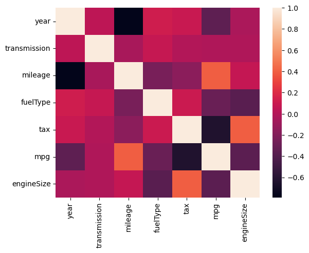

```python
sns.heatmap(X.iloc[:,1:].corr())
```

```python
from sklearn.model_selection import train_test_split
X_train, X_test, y_train, y_test = train_test_split(X, y, test_size = 0.2, random_state = 0)
```

```python
X_train
```

|  | model | year | transmission | mileage | fuelType | tax | mpg | engineSize |
| --- | --- | --- | --- | --- | --- | --- | --- | --- |
| 4929 | 0 | 2017 | 1 | 19229 | 2 | 30 | 56.5 | 1.4 |
| 9420 | 8 | 2019 | 0 | 6826 | 2 | 145 | 33.2 | 2.0 |
| 8756 | 0 | 2014 | 2 | 18954 | 2 | 125 | 53.3 | 1.4 |
| 9758 | 25 | 2014 | 1 | 27400 | 2 | 265 | 35.8 | 2.0 |
| 9341 | 2 | 2019 | 0 | 750 | 0 | 145 | 52.3 | 1.6 |
| ... | ... | ... | ... | ... | ... | ... | ... | ... |
| 9225 | 4 | 2016 | 0 | 106000 | 0 | 200 | 44.8 | 3.0 |
| 4859 | 10 | 2019 | 2 | 9415 | 0 | 150 | 38.2 | 2.0 |
| 3264 | 9 | 2017 | 2 | 23188 | 0 | 145 | 53.3 | 2.0 |
| 9845 | 25 | 2017 | 1 | 33105 | 2 | 145 | 47.1 | 1.8 |
| 2732 | 6 | 2020 | 2 | 2410 | 0 | 145 | 38.7 | 3.0 |

8534 rows × 8 columns

## We will be using Linear Regression, SVR, Random Forest Regressor, Extra Tree Regressor and Cat Boost Regressor

### Linear Regression

```python
from sklearn.linear_model import LinearRegression
lrmodel = LinearRegression()
```

```python
lrmodel.fit(X_train, y_train)
```

```
LinearRegression()
```

```python
lry_pred = lrmodel.predict(X_test)
```

```python
from sklearn.metrics import r2_score, mean_absolute_error, mean_squared_error
print(r2_score(lry_pred, y_test))
print(mean_squared_error(lry_pred, y_test))
print(mean_absolute_error(lry_pred, y_test))
```

```
0.7394834440270275
29225405.68320192
3431.2696131137227
```

### Support Vector Regressor

```python
from sklearn.svm import SVR
svrmodel = SVR()
```

```python
y_train = y_train.values
```

```python
y_train = y_train.ravel()
```

```python
svrmodel.fit(X_train, y_train)
```

```
SVR()
```

```python
svry_pred = svrmodel.predict(X_test)
```

```python
from sklearn.metrics import r2_score, mean_absolute_error, mean_squared_error
print(r2_score(svry_pred, y_test))
print(mean_squared_error(svry_pred, y_test))
print(mean_absolute_error(svry_pred, y_test))
```

```
-114.03415083996227
131853501.72903794
7621.4856981989
```

### Random Forest Regressor

```python
from sklearn.ensemble import RandomForestRegressor
```

```python
rfrmodel = RandomForestRegressor(random_state = 0)
```

```python
rfrmodel.fit(X_train, y_train)
```

```
RandomForestRegressor(random_state=0)
```

```python
rfry_pred = rfrmodel.predict(X_test)
```

```python
print(r2_score(rfry_pred, y_test))
print(mean_squared_error(rfry_pred, y_test))
print(mean_absolute_error(rfry_pred, y_test))
```

```
0.9518375004333299
6462709.30640574
1560.2109617717244
```

#### Random Forest Regressor with Randomize Search CV

```python
from sklearn.model_selection import RandomizedSearchCV
```

```python
rfrrscvmodel = RandomForestRegressor()
```

```python
rscv_params = {
    'n_estimators' : [int(x) for x in np.linspace(start = 80, stop = 1500, num = 10)],
    'max_features' : ['auto', 'sqrt'],
    'max_depth' : [int(x) for x in np.linspace(6, 45, num = 5)],
    'min_samples_split' : [2, 5, 10, 15, 100],
    'min_samples_leaf' : [1, 2, 5, 10]
}
```

```python
rscvrfrmodel = RandomizedSearchCV(estimator = rfrrscvmodel, param_distributions = rscv_params, scoring='neg_mean_squared_error',n_iter=3,cv=3,random_state=42, n_jobs = -1)
```

```python
%%time
rscvrfrmodel.fit(X_train, y_train)
```

```
CPU times: total: 2.62 s
Wall time: 31.3 s
```

```
RandomizedSearchCV(cv=3, estimator=RandomForestRegressor(), n_iter=3, n_jobs=-1,
                   param_distributions={'max_depth': [6, 15, 25, 35, 45],
                                        'max_features': ['auto', 'sqrt'],
                                        'min_samples_leaf': [1, 2, 5, 10],
                                        'min_samples_split': [2, 5, 10, 15,
                                                              100],
                                        'n_estimators': [80, 237, 395, 553, 711,
                                                         868, 1026, 1184, 1342,
                                                         1500]},
                   random_state=42, scoring='neg_mean_squared_error')
```

```python
rscvrfrmodel.best_params_
```

```
{'n_estimators': 80,
 'min_samples_split': 5,
 'min_samples_leaf': 2,
 'max_features': 'auto',
 'max_depth': 25}
```

```python
rscvrfrmodel.best_score_
```

```
-6161233.461094737
```

```python
rscvrfry_pred = rscvrfrmodel.predict(X_test)
```

```python
print(r2_score(rscvrfry_pred, y_test))
print(mean_squared_error(rscvrfry_pred, y_test))
print(mean_absolute_error(rscvrfry_pred, y_test))
```

```
0.9509484751537338
6548521.01684727
1561.7020157003294
```

#### Random Forest Regressor with Grid Search CV

```python
from sklearn.model_selection import GridSearchCV
```

```python
rfrgscvmodel = RandomForestRegressor()
```

```python
gscv_params = {
    'n_estimators' : [int(x) for x in np.linspace(start = 80, stop = 1500, num = 10)],
    'max_features' : ['auto', 'sqrt'],
    'max_depth' : [int(x) for x in np.linspace(6, 45, num = 5)],
    'min_samples_split' : [2, 5, 10, 15, 100],
    'min_samples_leaf' : [1, 2, 5, 10]
}
```

```python
rfrgscvmodel = GridSearchCV(estimator = rfrgscvmodel, param_grid = gscv_params, scoring='neg_mean_squared_error', cv=5, n_jobs = -1)
```

```python
%%time
rfrgscvmodel.fit(X_train, y_train)
```

```
CPU times: total: 38.7 s
Wall time: 3h 34min 1s
```

```
GridSearchCV(cv=5, estimator=RandomForestRegressor(), n_jobs=-1,
             param_grid={'max_depth': [6, 15, 25, 35, 45],
                         'max_features': ['auto', 'sqrt'],
                         'min_samples_leaf': [1, 2, 5, 10],
                         'min_samples_split': [2, 5, 10, 15, 100],
                         'n_estimators': [80, 237, 395, 553, 711, 868, 1026,
                                          1184, 1342, 1500]},
             scoring='neg_mean_squared_error')
```

```python
rfrgscvmodel.best_params_
```

```
{'max_depth': 15,
 'max_features': 'sqrt',
 'min_samples_leaf': 1,
 'min_samples_split': 2,
 'n_estimators': 553}
```

```python
rfrgscvmodel.best_score_
```

```
-5394565.192422843
```

```python
rfrgscvy_pred = rfrgscvmodel.predict(X_test)
```

```python
print(r2_score(rfrgscvy_pred, y_test))
print(mean_squared_error(rfrgscvy_pred, y_test))
print(mean_absolute_error(rfrgscvy_pred, y_test))
```

```
0.957448694808257
5452048.110696211
1481.934982651576
```

#### Both the CrossValidation models are used for hyperparameter tuning but the reason behind using both GridSearchCV and RandomizeSearchCV is

GridSearchCV exhaustively tries all the possible combinations of hyperparameters whereas RandomizeSearchCV samples a fixed number of hyperparameter setting from the specified probability distribution

GridSearchCV guarantees to find the best combination of hyperparameters within the specified search space whereas RandomizeSearchCV may not guarantee to find the absolute best combination of hyperparameters, it often finds a good set of hyperparameters in a much shorter time compared to GridSearchCV.

Thats the reason of GridSearchCV taking more time to execute compared to RandomizeSearchCV

GridsearchCV execution time --> 3h 34min

RandomizeSearchCV execution time --> 31s

### Extra Tree Regressor

```python
from sklearn.ensemble import ExtraTreesRegressor
```

```python
etrmodel = ExtraTreesRegressor()
```

```python
etrmodel.fit(X_train, y_train)
```

```
ExtraTreesRegressor()
```

```python
etry_pred = etrmodel.predict(X_test)
```

```python
print(r2_score(etry_pred, y_test))
print(mean_squared_error(etry_pred, y_test))
print(mean_absolute_error(etry_pred, y_test))
```

```
0.9566041802470104
5811769.070610439
1539.2543658231803
```

### Cat Boost Regressor

Soo, before using this model we need to install it first

```python
pip install catboost
```

[output not shown]

[output cut: 842 more lines]

[output not shown]

```python
from catboost import CatBoostRegressor
```

```python
catmodel = CatBoostRegressor()
```

CatBoost is particularly renowned for its ability to handle categorical features effectively without requiring preprocessing like one-hot encoding or label encoding

Soo, now I will be splitting the dataset again without encoding the data since, I have encoded 3 features i.e., 'fuel', 'model', 'transmission' and now I will not be using that

```python
dfcat = pd.read_csv('audi.csv')
dfcat.head()
```

|  | model | year | price | transmission | mileage | fuelType | tax | mpg | engineSize |
| --- | --- | --- | --- | --- | --- | --- | --- | --- | --- |
| 0 | A1 | 2017 | 12500 | Manual | 15735 | Petrol | 150 | 55.4 | 1.4 |
| 1 | A6 | 2016 | 16500 | Automatic | 36203 | Diesel | 20 | 64.2 | 2.0 |
| 2 | A1 | 2016 | 11000 | Manual | 29946 | Petrol | 30 | 55.4 | 1.4 |
| 3 | A4 | 2017 | 16800 | Automatic | 25952 | Diesel | 145 | 67.3 | 2.0 |
| 4 | A3 | 2019 | 17300 | Manual | 1998 | Petrol | 145 | 49.6 | 1.0 |

```python
dfcat.shape
```

```
(10668, 9)
```

```python
Xa = dfcat.iloc[:,[0,1,3,4,5,6,7,8]]
ya = dfcat.iloc[:,2:3]
```

```python
Xa.shape
```

```
(10668, 8)
```

```python
ya.shape
```

```
(10668, 1)
```

```python
from sklearn.model_selection import train_test_split
Xa_train, Xa_test, ya_train, ya_test = train_test_split(Xa, ya, test_size = 0.2, random_state = 0)
```

Soo, now we need to convert the ya_test dataset to 1d array in order to ignore future errors

```python
ya_test = ya_test.values
```

```python
ya_test = ya_test.ravel()
ya_test
```

```
array([14998, 21950, 28990, ..., 45995, 30500,  8400], dtype=int64)
```

Successfully converted into 1D array

```python
catmodel.fit(Xa_train, ya_train)
```

[output not shown]

[output cut: 31 more lines]

[output not shown]

I guess there must be some error which the model lead to unable to encode the 'model' column, so unfortunately we will be drping this idea and wil be continueing with the previous train test split or else I am having less knowledge about this model

```python
catmodel.fit(X_train, y_train)
```

[output not shown]

[output cut: 946 more lines]

[output not shown]

```
<catboost.core.CatBoostRegressor at 0x1ddaf231d10>
```

```python
caty_pred = catmodel.predict(X_test)
```

```python
print(r2_score(caty_pred, y_test))
print(mean_squared_error(caty_pred, y_test))
print(mean_absolute_error(caty_pred, y_test))
```

```
0.9636310859243442
4809524.71579828
1438.9059250244693
```

### Displaying all the model's r2_score, Mean_squared_error and Mean_absolute_error

```python
print('Linear Regression')
print('R-Squared Score', r2_score(lry_pred, y_test))
print('Mean_Squared_Error', mean_squared_error(lry_pred, y_test))
print('Mean_Absolute_Error', mean_absolute_error(lry_pred, y_test))
print()

print('SVR')
print('R-Squared Score', r2_score(svry_pred, y_test))
print('Mean_Squared_Error', mean_squared_error(svry_pred, y_test))
print('Mean_Absolute_Error', mean_absolute_error(svry_pred, y_test))
print()

print('Random Forest Regressor')
print('R-Squared Score', r2_score(rfry_pred, y_test))
print('Mean_Squared_Error', mean_squared_error(rfry_pred, y_test))
print('Mean_Absolute_Error', mean_absolute_error(rfry_pred, y_test))
print()

print('Random Forest Regressor using Randomize Search CV')
print('R-Squared Score', r2_score(rscvrfry_pred, y_test))
print('Mean_Squared_Error', mean_squared_error(rscvrfry_pred, y_test))
print('Mean_Absolute_Error', mean_absolute_error(rscvrfry_pred, y_test))
print()

print('Random Forest Regressor using Grid Search CV')
print('R-Squared Score', r2_score(rfrgscvy_pred, y_test))
print('Mean_Squared_Error', mean_squared_error(rfrgscvy_pred, y_test))
print('Mean_Absolute_Error', mean_absolute_error(rfrgscvy_pred, y_test))
print()

print('Extra Tree Regressor')
print('R-Squared Score', r2_score(etry_pred, y_test))
print('Mean_Squared_Error', mean_squared_error(etry_pred, y_test))
print('Mean_Absolute_Error', mean_absolute_error(etry_pred, y_test))
print()

print('Cat Boost Regressor')
print('R-Squared Score', r2_score(caty_pred, y_test))
print('Mean_Squared_Error', mean_squared_error(caty_pred, y_test))
print('Mean_Absolute_Error', mean_absolute_error(caty_pred, y_test))
```

```
Linear Regression
R-Squared Score 0.7394834440270275
Mean_Squared_Error 29225405.68320192
Mean_Absolute_Error 3431.2696131137227

SVR
R-Squared Score -114.03415083996227
Mean_Squared_Error 131853501.72903794
Mean_Absolute_Error 7621.4856981989

Random Forest Regressor
R-Squared Score 0.9518375004333299
Mean_Squared_Error 6462709.30640574
Mean_Absolute_Error 1560.2109617717244

Random Forest Regressor using Randomize Search CV
R-Squared Score 0.9509484751537338
Mean_Squared_Error 6548521.01684727
Mean_Absolute_Error 1561.7020157003294

Random Forest Regressor using Grid Search CV
R-Squared Score 0.957448694808257
Mean_Squared_Error 5452048.110696211
Mean_Absolute_Error 1481.934982651576

Extra Tree Regressor
R-Squared Score 0.9566041802470104
Mean_Squared_Error 5811769.070610439
Mean_Absolute_Error 1539.2543658231803

Cat Boost Regressor
R-Squared Score 0.9636310859243442
Mean_Squared_Error 4809524.71579828
Mean_Absolute_Error 1438.9059250244693
```

## Creating Pickle File

```python
import pickle
pickle.dump(catmodel, open('model.pkl','wb'))
```

```python
model=pickle.load(open('model.pkl','rb'))
print (model.predict (X_test))
```

```
[13364.92184756 24244.56730406 27964.98679055 ... 46818.6680263
 31730.82502629  9356.64383379]
```